# P-Hackers Project Proposal

Oscar Fawcett, Yesh Munagala, Ian Morton, Weston Murdock, and Emily Przykucki

3/10/2022

## Description

We have chosen to work with the Drug Consumption dataset which contains 1885 observations and 31 variables. This data contains demographic and personality information of each respondent as well as the reported drug use frequency for various different drugs. Below are the descriptions of each variable in the dataset along with the first six rows:

- `age`: age range of respondent
- `gender`: gender of respondent
- `education`: education level of respondent
- `country`: country of current residence of respondent
- `ethnicity`: ethnic identity of respondent
- `nscore`: neuroticism score of respondent from the NEO-FFI-R questionnaire
- `escore`: extroversion score of respondent from the NEO-FFI-R questionnaire
- `oscore`: openness score of respondent from the NEO-FFI-R questionnaire
- `ascore`: agreeableness score of respondent from the NEO-FFI-R questionnaire
- `cscore`: conscientiousness score of respondent from the NEO-FFI-R questionnaire
- `impulsive`: impulsiveness score of respondent measured by the BIS-11 questionnaire
- `ss`: sensation seeing of respondent measured by the ImpSS scale
- `alcohol`: the time frame for when alcohol was last consumed by the respondent
- `amphet`: the time frame for when amphetamines was last consumed by the respondent
- `amyl`: the time frame for when amyl nitrite was last consumed by the respondent
- `benzos`: the time frame for benzodiazepine was last consumed by the respondent
- `caff`: the time frame for when caffeine was last consumed by the respondent
- `cannabis`: the time frame for when cannabis was last consumed by the respondent
- `choc`: the time frame for when chocolate was last consumed by the respondent
- `coke`: the time frame for when cocaine was last consumed by the respondent
- `crack`: the time frame for when crack was last consumed by the respondent
- `ecstasy`: the time frame for when ecstasy was last consumed by the respondent
- `heroin`: the time frame for when heroin was last consumed by the respondent
- `ketamine`: the time frame for when ketamine was last consumed by the respondent
- `legalh`: the time frame for when the respondent had a legal high last
- `lsd`: the time frame for when Lysergic acid diethylamide (known also as acid or LSD) was last consumed by the respondent
- `meth`: the time frame for when methadone was last consumed by the respondent
- `mushrooms`: the time frame for when magic mushrooms were last consumed by the respondent
- `nicotine`: the time frame for when nicotine was last consumed by the respondent
- `semer`: the time frame for when a fictitious drug Semeron was last consumed by the respondent
- `vsa`: the time frame for when volatile consumption abuse was last consumed by the respondent

|  | index | age | gender | education | country | ethnicity | nscore | escore | oscore | ascore | cscore | impulsive | ss | alcohol | amphet | amyl | benzos | caff | cannabis | choc | coke | crack | ecstasy | heroin | ketamine | legalh | lsd | meth | mushrooms | … |
| --- | --- | --- | --- | --- | --- | --- | --- | --- | --- | --- | --- | --- | --- | --- | --- | --- | --- | --- | --- | --- | --- | --- | --- | --- | --- | --- | --- | --- | --- | --- |
| 1 | 1 | 35-44 | Female | professional certificate or diploma | United Kingdom | Asian/White | 0.31287 | -0.57545 | -0.58331 | -0.91699 | -0.00665 | -0.21712 | -1.18084 | CL5 | CL2 | CL0 | CL2 | CL6 | CL0 | CL5 | CL0 | CL0 | CL0 | CL0 | CL0 | CL0 | CL0 | CL0 | CL0 | … |
| 2 | 2 | 25-34 | Male | doctorate degree | United Kingdom | White | -0.67825 | 1.93886 | 1.43533 | 0.76096 | -0.14277 | -0.71126 | -0.21575 | CL5 | CL2 | CL2 | CL0 | CL6 | CL4 | CL6 | CL3 | CL0 | CL4 | CL0 | CL2 | CL0 | CL2 | CL3 | CL0 | … |
| 3 | 3 | 35-44 | Male | professional certificate or diploma | United Kingdom | White | -0.46725 | 0.80523 | -0.84732 | -1.62090 | -1.01450 | -1.37983 | 0.40148 | CL6 | CL0 | CL0 | CL0 | CL6 | CL3 | CL4 | CL0 | CL0 | CL0 | CL0 | CL0 | CL0 | CL0 | CL0 | CL1 | … |
| 4 | 4 | 18-24 | Female | masters degree | United Kingdom | White | -0.14882 | -0.80615 | -0.01928 | 0.59042 | 0.58489 | -1.37983 | -1.18084 | CL4 | CL0 | CL0 | CL3 | CL5 | CL2 | CL4 | CL2 | CL0 | CL0 | CL0 | CL2 | CL0 | CL0 | CL0 | CL0 | … |
| 5 | 5 | 35-44 | Female | doctorate degree | United Kingdom | White | 0.73545 | -1.63340 | -0.45174 | -0.30172 | 1.30612 | -0.21712 | -0.21575 | CL4 | CL1 | CL1 | CL0 | CL6 | CL3 | CL6 | CL0 | CL0 | CL1 | CL0 | CL0 | CL1 | CL0 | CL0 | CL2 | … |
| 6 | 6 | 65+ | Female | left school at 18 | Canada | White | -0.67825 | -0.30033 | -1.55521 | 2.03972 | 1.63088 | -1.37983 | -1.54858 | CL2 | CL0 | CL0 | CL0 | CL6 | CL0 | CL4 | CL0 | CL0 | CL0 | CL0 | CL0 | CL0 | CL0 | CL0 | CL0 | … |

Note: for the drug variables, the levels CL0 through CL6 refer to the different classes represented in the dataset, defined as follows:

- `CL0`: Never Used
- `CL1`: Used over a Decade Ago
- `CL2`: Used in Last Decade
- `CL3`: Used in Last Year
- `CL4`: Used in Last Month
- `CL5`: Used in Last Week
- `CL6`: Used in Last Day

This dataset can be found at the following link: https://archive.ics.uci.edu/ml/datasets/Drug+consumption+%28quantified%29

## Motivation and Goals

In analyzing this data set, we hope to gain a better idea of how to predict whether or not someone may use drugs based on a variety of observed traits, and which drugs they may use, as well as examine how the usage of different drugs may be related to one another. This is motivated by a desire to better understand drug use habits, what factors influence drug usage, and find ways to provide better care to people with drug addictions, and anticipate what kinds of care may be needed, when combined with knowledge of the different types of treatments each drug may require, and how usage of multiple drugs may affect this. Furthermore, by finding correlations between the usage of different drugs and various personality traits, we may encounter interesting links between these two areas that could prompt further studies and data collection in order to more thoroughly understand these drugs and the usage habits associated with them.

## Exploratory Data Analysis

First, we will create histograms and barplots of each variable in our data set to visualize each variable’s distribution:

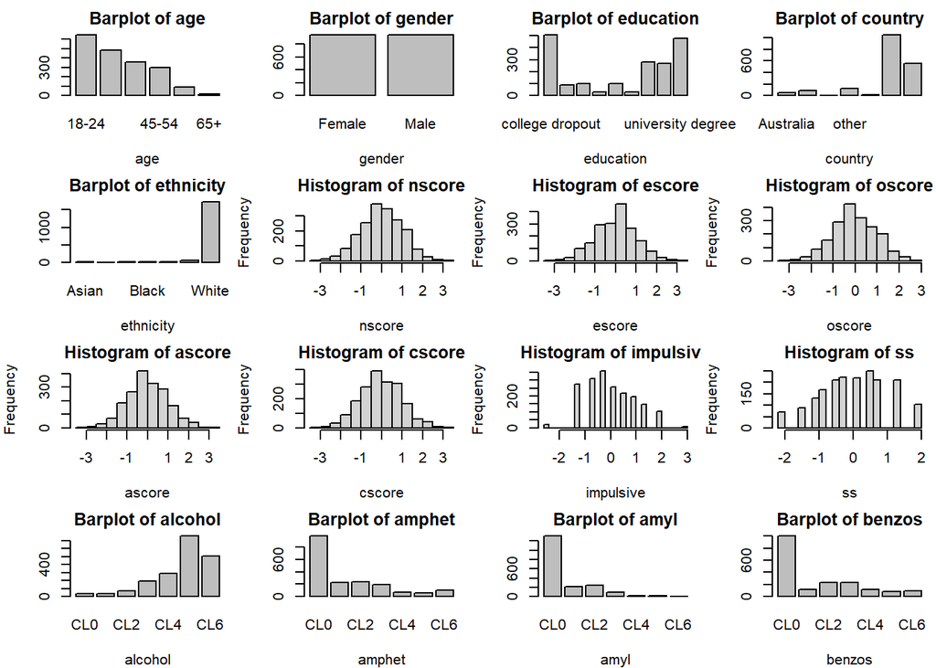

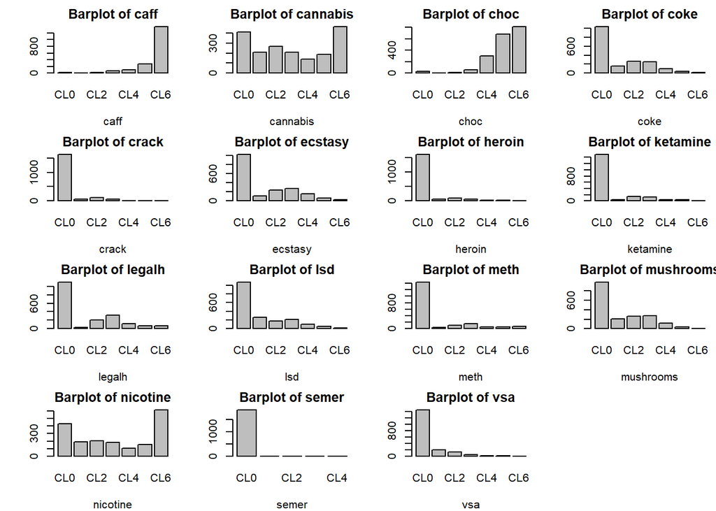

Now, we will investigate the correlations between the real variables:

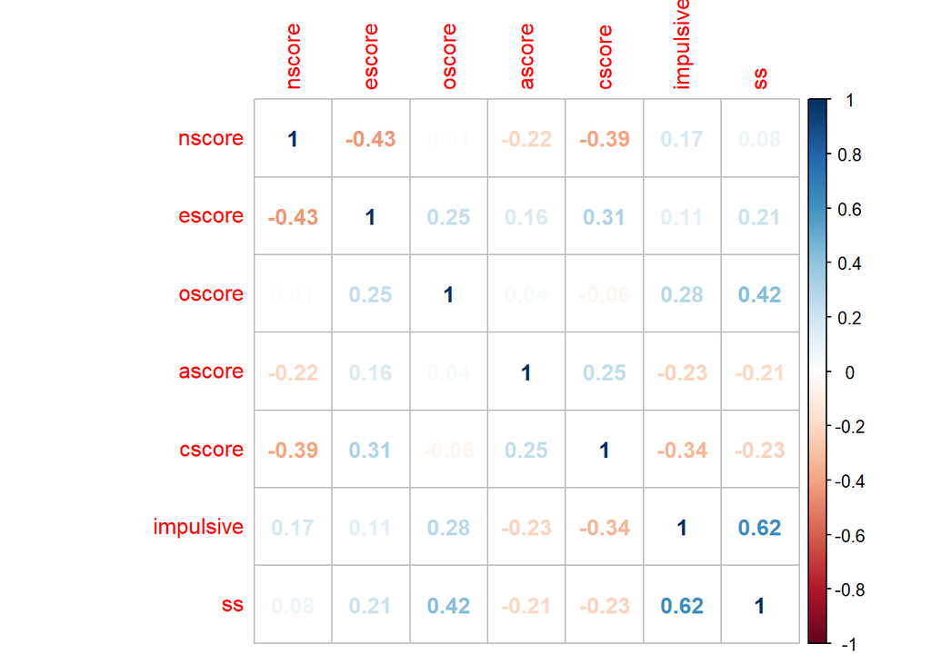

Looking at the above correlation plot, most variables have a very weak relationship with one another. However, ss appears to have a moderate relationship with oscore and impulsive, and escore has a moderate negative relationship with nscore.

Let us now create a simple multinomial logistic regression model for cannabis consumption so that we may begin to tackle our problem. We will only use the personality score variables for preliminary interpretation:

```r
#Multinomial logistic regression with only personality data
mod = multinom(cannabis ~ nscore + escore + oscore + ascore + cscore,drug)
summary(mod)
```

```
## Call:
## multinom(formula = cannabis ~ nscore + escore + oscore + ascore +
##     cscore, data = drug)
##
## Coefficients:
##     (Intercept)      nscore     escore    oscore      ascore     cscore
## CL1 -0.44584590 -0.23024964 -0.2262606 0.3829812 -0.09272595 -0.2457531
## CL2 -0.09943197  0.07857180 -0.1126545 0.5509234 -0.34894885 -0.3247961
## CL3 -0.34378181  0.08496134 -0.2096627 0.9965265 -0.27880889 -0.6967885
## CL4 -0.82098212 -0.11562991 -0.1595417 1.1856176 -0.40469845 -0.8829997
## CL5 -0.56546128 -0.11122012 -0.1989036 1.3756905 -0.27473364 -0.7727865
## CL6  0.29087285 -0.17057371 -0.2286837 1.4721020 -0.44545912 -0.7979372
##
## Std. Errors:
##     (Intercept)     nscore     escore     oscore     ascore     cscore
## CL1  0.10319423 0.10449381 0.10521224 0.09996544 0.09179923 0.10230818
## CL2  0.09290400 0.09896804 0.09809105 0.09478809 0.08696172 0.09532767
## CL3  0.09902142 0.10832202 0.10751810 0.10638401 0.09544628 0.10646553
## CL4  0.11582476 0.12206342 0.12213772 0.12326763 0.11018070 0.12301611
## CL5  0.10724480 0.11254189 0.11242976 0.11467407 0.10081680 0.11193282
## CL6  0.08700828 0.09217878 0.09200570 0.09523738 0.08248928 0.09152702
##
## Residual Deviance: 6412.673
## AIC: 6484.673
```

```r
#two-tailed z test
z = summary(mod)$coefficients/summary(mod)$standard.errors
p = (1 - pnorm(abs(z), 0, 1)) * 2
p
```

```
##      (Intercept)     nscore     escore       oscore       ascore       cscore
## CL1 1.557087e-05 0.02756119 0.03151445 1.275529e-04 3.124498e-01 1.630184e-02
## CL2 2.844997e-01 0.42724733 0.25077527 6.167263e-09 6.003534e-05 6.564386e-04
## CL3 5.169959e-04 0.43284040 0.05117344 0.000000e+00 3.487889e-03 5.960188e-11
## CL4 1.359357e-12 0.34348911 0.19146940 0.000000e+00 2.396790e-04 7.078782e-13
## CL5 1.344883e-07 0.32302762 0.07687111 0.000000e+00 6.428632e-03 5.055067e-12
## CL6 8.286353e-04 0.06424641 0.01293557 0.000000e+00 6.656437e-08 0.000000e+00
```

## Ideas and Techniques

At first glance, since this dataset has a large number of observations and a relatively small number of variables, it may appear that we won’t need to employ any dimension reduction techniques. However, we may still want to perform PCA analysis on the real variables in our dataset.

One avenue that we plan on exploring is creating new variables that combine different levels of the other drug variables together to create a new drug category. We would then use these new variables as the response for our models. As for predictive models, we plan on applying multinomial logistic regression, SVM, and K-nn analysis to our data in the hopes that we can find one that provides strong predictive power with regards to a test dataset.